# Homework 2: *Learning pandas*

### Part 1. Basic pandas (10 points for each problem below)

Consider the following Python dictionary *data* and Python list *labels*:

> data = {'animal': ['cat', 'cat', 'snake', 'dog', 'dog', 'cat', 'snake','cat', 'dog', 'dog'], 'age': [2.5, 3, 0.5, np.nan, 5, 2, 4.5, np.nan, 7, 3], 'visits': [1, 3, 2, 3, 2, 3, 1, 1, 2, 1], 'priority': ['yes', 'yes', 'no', 'yes', 'no', 'no', 'no', 'yes', 'no', 'no']}

> labels = ['a', 'b', 'c', 'd', 'e', 'f', 'g', 'h', 'i', 'j']

#### 1. Create a DataFrame *df* from this dictionary *data* which has the index given by *labels*.

```python
import pandas as pd
import numpy as np

data = {'animal': ['cat', 'cat', 'snake', 'dog', 'dog', 'cat', 'snake','cat', 'dog', 'dog'],
        'age': [2.5, 3, 0.5, np.nan, 5, 2, 4.5, np.nan, 7, 3],
        'visits': [1, 3, 2, 3, 2, 3, 1, 1, 2, 1],
        'priority': ['yes', 'yes', 'no', 'yes', 'no', 'no', 'no', 'yes', 'no', 'no']}
labels = ['a', 'b', 'c', 'd', 'e', 'f', 'g', 'h', 'i', 'j']

df = pd.DataFrame(data, labels)
df
```

|  | animal | age | visits | priority |
| --- | --- | --- | --- | --- |
| a | cat | 2.5 | 1 | yes |
| b | cat | 3.0 | 3 | yes |
| c | snake | 0.5 | 2 | no |
| d | dog | NaN | 3 | yes |
| e | dog | 5.0 | 2 | no |
| f | cat | 2.0 | 3 | no |
| g | snake | 4.5 | 1 | no |
| h | cat | NaN | 1 | yes |
| i | dog | 7.0 | 2 | no |
| j | dog | 3.0 | 1 | no |

#### 2. Select just the *'animal'* and *'age'* columns from the DataFrame *df*.

```python
df.loc[:,['animal', 'age']]
```

|  | animal | age |
| --- | --- | --- |
| a | cat | 2.5 |
| b | cat | 3.0 |
| c | snake | 0.5 |
| d | dog | NaN |
| e | dog | 5.0 |
| f | cat | 2.0 |
| g | snake | 4.5 |
| h | cat | NaN |
| i | dog | 7.0 |
| j | dog | 3.0 |

#### 3.Change the age in row *'f'* to 1.5.

```python
df.loc['f', 'age'] = 1.5
df
```

|  | animal | age | visits | priority |
| --- | --- | --- | --- | --- |
| a | cat | 2.5 | 1 | yes |
| b | cat | 3.0 | 3 | yes |
| c | snake | 0.5 | 2 | no |
| d | dog | NaN | 3 | yes |
| e | dog | 5.0 | 2 | no |
| f | cat | 1.5 | 3 | no |
| g | snake | 4.5 | 1 | no |
| h | cat | NaN | 1 | yes |
| i | dog | 7.0 | 2 | no |
| j | dog | 3.0 | 1 | no |

#### 4. Select the rows where the *animal* is a cat and the *age* is less than 3.

```python
df.loc[(df['age']<3)&(df['animal'] == 'cat')]
```

|  | animal | age | visits | priority |
| --- | --- | --- | --- | --- |
| a | cat | 2.5 | 1 | yes |
| f | cat | 1.5 | 3 | no |

#### 5. Calculate the mean *age* for each different *animal* in *df*.

```python
df.groupby('animal')['age'].agg(np.mean)
```

```
animal
cat      2.333333
dog      5.000000
snake    2.500000
Name: age, dtype: float64
```

#### 6. Append a new row *'k'* to *df* with your choice of values for each column. Then delete that row to return the original DataFrame.

```python
df.loc['k'] = ['tiger', 10, 5, 'yes']
df.drop('k', inplace = True)
df
```

|  | animal | age | visits | priority |
| --- | --- | --- | --- | --- |
| a | cat | 2.5 | 1 | yes |
| b | cat | 3.0 | 3 | yes |
| c | snake | 0.5 | 2 | no |
| d | dog | NaN | 3 | yes |
| e | dog | 5.0 | 2 | no |
| f | cat | 1.5 | 3 | no |
| g | snake | 4.5 | 1 | no |
| h | cat | NaN | 1 | yes |
| i | dog | 7.0 | 2 | no |
| j | dog | 3.0 | 1 | no |

#### 7. Sort *df* first by the values in the *'age'* in descending order, then by the value in the *'visit'* column in ascending order.

```python
df.sort_values(by = ['age','visits'], ascending = [False, True])
```

|  | animal | age | visits | priority |
| --- | --- | --- | --- | --- |
| i | dog | 7.0 | 2 | no |
| e | dog | 5.0 | 2 | no |
| g | snake | 4.5 | 1 | no |
| j | dog | 3.0 | 1 | no |
| b | cat | 3.0 | 3 | yes |
| a | cat | 2.5 | 1 | yes |
| f | cat | 1.5 | 3 | no |
| c | snake | 0.5 | 2 | no |
| h | cat | NaN | 1 | yes |
| d | dog | NaN | 3 | yes |

### Part 2: Stocks Data (30 Points)

#### 1. Download SPY, AIG, AMZN, JPM, F monthly price data from Yahoo! as your test data in .csv format from (2012/12 to 2017/12) for total 61 months.

#### 2. Write a Python code to load these data to a pandas.DataFrame object, such that index are calendar month, columns are stock names.

```python
import pandas as pd

spy = pd.read_csv('SPY.csv', index_col = 0).iloc[:, 4]
f = pd.read_csv('F.csv', index_col = 0).iloc[:, 4]
aig = pd.read_csv('AIG.csv', index_col = 0).iloc[:, 4]
amzn = pd.read_csv('AMZN.csv', index_col = 0).iloc[:, 4]
jpm = pd.read_csv('JPM.csv', index_col = 0).iloc[:, 4]

stock_price = pd.DataFrame([spy, aig, amzn, jpm, f]).transpose()
stock_price.columns=['SPY', 'AIG', 'AMZN', 'JPM', 'F']
stock_price.head(15)
```

| Date | SPY | AIG | AMZN | JPM | F |
| --- | --- | --- | --- | --- | --- |
| 2012-12-01 | 123.804222 | 31.460365 | 250.869995 | 36.300701 | 9.094471 |
| 2013-01-01 | 131.064804 | 33.715179 | 265.500000 | 38.843487 | 9.094471 |
| 2013-02-01 | 132.737045 | 33.875587 | 264.269989 | 40.664764 | 8.920907 |
| 2013-03-01 | 137.167130 | 34.597492 | 266.489990 | 39.451145 | 9.302929 |
| 2013-04-01 | 140.424194 | 36.914680 | 253.809998 | 40.739582 | 9.699100 |
| 2013-05-01 | 143.739563 | 39.624020 | 269.200012 | 45.661690 | 11.092769 |
| 2013-06-01 | 141.074951 | 39.837914 | 277.690002 | 44.156075 | 11.024618 |
| 2013-07-01 | 149.150391 | 40.559807 | 301.220001 | 46.615238 | 12.029448 |
| 2013-08-01 | 144.676941 | 41.406464 | 280.980011 | 42.573914 | 11.605673 |
| 2013-09-01 | 148.531448 | 43.340454 | 312.640015 | 43.551281 | 12.093126 |
| 2013-10-01 | 156.167023 | 46.125721 | 364.029999 | 43.424896 | 12.265167 |
| 2013-11-01 | 160.795441 | 44.428936 | 393.619995 | 48.565746 | 12.313586 |
| 2013-12-01 | 164.073532 | 45.589893 | 398.790009 | 49.635166 | 11.124041 |
| 2014-01-01 | 159.149597 | 42.916729 | 358.690002 | 46.987057 | 10.785201 |
| 2014-02-01 | 166.393433 | 44.536396 | 362.100006 | 48.541668 | 11.184134 |

#### 3. Calculate monthly returns of these stocks as a pandas.DateFrame object

```python
price0 = stock_price.shift(1)
stock_return = stock_price.diff()/price0
stock_return.dropna(inplace = True)
stock_return.head()
```

| Date | SPY | AIG | AMZN | JPM | F |
| --- | --- | --- | --- | --- | --- |
| 2013-01-01 | 0.058646 | 0.071672 | 0.058317 | 0.070048 | 0.000000 |
| 2013-02-01 | 0.012759 | 0.004758 | -0.004633 | 0.046888 | -0.019085 |
| 2013-03-01 | 0.033375 | 0.021310 | 0.008401 | -0.029844 | 0.042823 |
| 2013-04-01 | 0.023745 | 0.066976 | -0.047581 | 0.032659 | 0.042586 |
| 2013-05-01 | 0.023610 | 0.073395 | 0.060636 | 0.120819 | 0.143691 |

#### 4. Calculate normalized returns for these stocks as a pandas.DateFrame object: $R_n = \frac{R-R_{avg}}{\sigma}$

```python
# stock_return.index = pd.to_datetime(stock_return.index)
normal_return = (stock_return - stock_return.mean())/stock_return.std()
normal_return.head()
stock_return.describe()
```

|  | SPY | AIG | AMZN | JPM | F |
| --- | --- | --- | --- | --- | --- |
| count | 60.000000 | 60.000000 | 60.000000 | 60.000000 | 60.000000 |
| mean | 0.012638 | 0.011268 | 0.028731 | 0.018841 | 0.004622 |
| std | 0.028439 | 0.053591 | 0.076238 | 0.056937 | 0.056144 |
| min | -0.053872 | -0.125469 | -0.131516 | -0.131032 | -0.152590 |
| 25% | -0.003557 | -0.017927 | -0.022592 | -0.010400 | -0.021207 |
| 50% | 0.014307 | 0.019498 | 0.022268 | 0.026302 | 0.003314 |
| 75% | 0.028413 | 0.044852 | 0.074636 | 0.051089 | 0.031835 |
| max | 0.095736 | 0.132187 | 0.235113 | 0.165937 | 0.143691 |

#### 5. Calculate the correlation matrix of these stocks

```python
stock_return.corr()
```

|  | SPY | AIG | AMZN | JPM | F |
| --- | --- | --- | --- | --- | --- |
| SPY | 1.000000 | 0.606271 | 0.549665 | 0.556832 | 0.618131 |
| AIG | 0.606271 | 1.000000 | 0.349058 | 0.524451 | 0.471738 |
| AMZN | 0.549665 | 0.349058 | 1.000000 | 0.204424 | 0.325026 |
| JPM | 0.556832 | 0.524451 | 0.204424 | 1.000000 | 0.463197 |
| F | 0.618131 | 0.471738 | 0.325026 | 0.463197 | 1.000000 |

#### 6. Perform a Student’s t-test to exam whether AIG, AMZN, JPM, F have significant difference in mean relative to the index SPY return

```python
import scipy.stats as stats
print('t-Statistic:')
print(stats.ttest_ind(stock_return, stock_return['SPY']).statistic)
print('\np-Value:')
print(stats.ttest_ind(stock_return, stock_return['SPY']).pvalue)
```

```
t-Statistic:
[-3.34101445e-16 -1.74923965e-01  1.53203356e+00  7.54983237e-01
 -9.86515290e-01]

p-Value:
[1.         0.86143917 0.12819082 0.45176328 0.32589883]
```

### Part 3. *XCEL* data Loading (Bonus 20 points)

Read https://pandas.pydata.org/pandas-docs/stable/generated/pandas.read_excel.html and learn how to read in a data from Excel file in pandas.

#### 1. Download US Treasury 2Y, 10Y Constant Maturity Treasury monthly rates and GDP growth rate changes from FED St. Louis website as Excel file

https://fred.stlouisfed.org/series/GS2

https://fred.stlouisfed.org/series/GS10

https://fred.stlouisfed.org/graph/?id=A191RP1Q027SBEA

#### 2. Upload these original data files to your Python code. Test whether there is a relationship between treasury rates inverting (10Y – 2Y < 0) and economic recessions (GDP growth rates change < 0).

> a. Use matplotlib to plot the time series of treasury rates slop (10Y – 2Y) and the GDP growth rate changes.

> b. Exam a lead-lag relationship between negative slope (continue for three months) and lagged (3 months, 6 months) GDP growth rate changes.

#### This is an open topic, extra effort and results will be awarded for bonus points up to 20 points.

```python
%matplotlib notebook
import matplotlib as mpl
import matplotlib.pyplot as plt
mpl.use('nbAgg')
```

```python
import pandas as pd
gs2 = pd.read_excel('GS2.xls', header = 10, index_col = 0)
gs10 = pd.read_excel('GS10.xls', header = 10, index_col = 0)
gdp = pd.read_excel('A191RP1Q027SBEA.xls', header = 10, index_col = 0)
```

```python
gs_all = pd.merge(gs10, gs2, how = 'inner', left_index = True, right_index = True)
gs_all['Diff']= gs_all['GS10'] - gs_all['GS2']
gdp.columns = ['GDP']
# gdp_2q = (gdp + gdp.shift())/2
# gdp_8q = (gdp + gdp.shift(1)+gdp.shift(2)+gdp.shift(3)+gdp.shift(4)+gdp.shift(5)+gdp.shift(6)+gdp.shift(7))/8
```

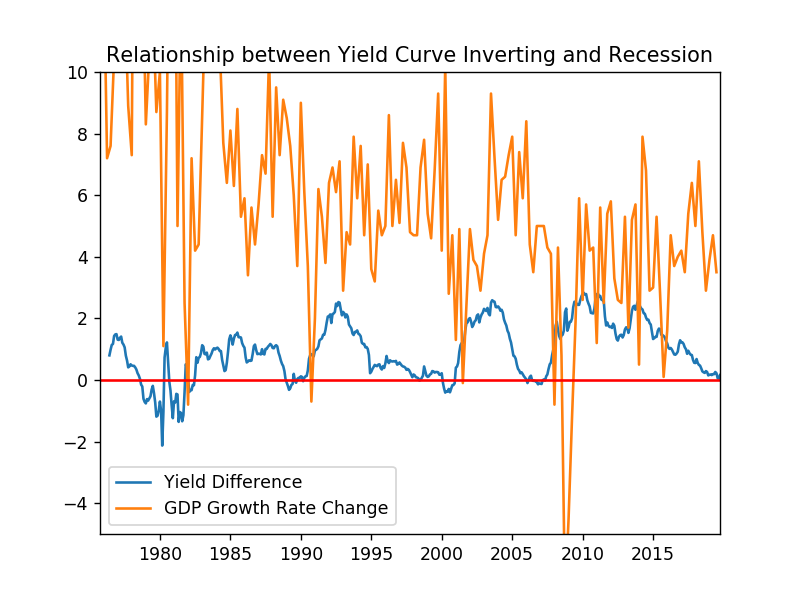

```python
plt.figure()
plt.plot(gs_all.index, gs_all['Diff'], label= 'Yield Difference')
plt.plot(gdp.index,gdp['GDP'], label = 'GDP Growth Rate Change')
xx = pd.to_datetime(['1953-04-01', '2019-10-01'])
yy = [0,0]
plt.xlim('1975-10-01', '2019-10-01' )
plt.ylim(-5, 10)
plt.plot(xx,yy,'-r')
plt.legend()
plt.title('Relationship between Yield Curve Inverting and Recession')
# plt.plot(gs_all.index, gs_all['GS1'], '-g')
# gdp_diff = gdp.diff()
# plt.plot(gdp_diff.index, gdp_diff['GDP'], '-y')
# plt.plot(gdp.index,gdp['GDP'], '-k',label = 'GDP Growth Rate Change')
```

#### Based on abive results, we can see the interest curve inversion has a predicative power to the future economic recession as many discussed in [mass media](https://www.forbes.com/sites/greatspeculations/2019/10/02/inverted-yield-curve-suggesting-recession-around-the-corner/#7cbf320d2345). We certainly can further ask:

1. Is this lead-lag relation valid for a longer historical period?
2. Is a monthly (10Y - 2Y) the best measure in predicting recession?
3. Can we have a more quantitative way to describe this predictive model?